# PLSC30500, Fall 2024

Part 4. Regression (part a)

Andy Eggers

## Regression motivation

It’s great if your estimator is as simple as a sample mean $\overline{X}$ or a difference in sample means $\overline{Y}_1 - \overline{Y}_0$.

But $>95\%$ of the time researchers in social science use **OLS regression**:

- predict $Y$ using many predictors $X_{[1]}, X_{[2]}, \ldots$
- relationship between $Y$ and $X_{[1]}$ *controlling for* or *adjusting for* other variables
- or just a difference in sample means! $\overline{Y}_1 - \overline{Y}_0$

To understand it we’ll use (almost) everything we have learned.

# Regression theory

## BLP with one predictor

- CEF (conditional expectation function): ${\textrm E}[Y \mid X]$. Could be any shape.
- BLP (best linear predictor): MSE-minimizing slope and intercept, i.e.
  $$(\alpha, \beta) = \underset{(a,b) \in \mathbb{R}^2}{\arg\min} \, \mathrm{E}\,[\left(Y - (a + bX)\right)^2]$$
- Can be viewed as BLP of $Y$ or BLP of CEF (${\textrm E}[Y \mid X]$)
- **Solution**: $\beta = \frac{\text{Cov}[X, Y]}{{\textrm V}[X]}$, $\alpha = {\textrm E}[Y] - \beta {\textrm E}[X]$

**Plug-in estimator**: to get $\hat{\alpha}$, $\hat{\beta}$, plug in sample covariance, sample variance, sample means to solution above

## Errors and residuals

Given a prediction $\hat{Y}_i$ for an observation $i$, the **residual** is

$$e_i = Y_i - \hat{Y}_i$$

If the prediction $\hat{Y}_i$ is based on a true population predictor (e.g. CEF or BLP), then $e_i = Y_i - \hat{Y}$ can be called an **error**.

(Residual : error :: Sample mean $\overline{X}$ : expectation ${\textrm E}[X]$)

## BLP with multiple predictors

- CEF (conditional expectation function): ${\textrm E}[Y \mid \mathbf{X}]$. Could be any shape.
- BLP (best linear predictor): MSE-minimizing vector of coefficients, i.e.
  $$(\beta_0, \beta_1, \ldots, \beta_K) = \underset{(b_0, b_1, \ldots, b_K) \in \mathbb{R}^{K+1}}{\arg\min} \, \mathrm{E}\,[\left(Y - (b_0 + b_1X_{[1]} + \ldots + b_K X_{[K]})\right)^2]$$
- Can be viewed as BLP of $Y$ or BLP of CEF (${\textrm E}[Y \mid \mathbf{X}]$)
- **Solution**: no simpler statement than the problem above (except $\left(\mathbb{X}'\mathbb{X}\right)^{-1} \, \mathbb{X}'\mathbf{Y}$)

**Plug-in estimator** (Ordinary Least Squares, OLS):

$$(\hat{\beta_0}, \hat{\beta_1}, \ldots, \hat{\beta_K}) = \underset{(b_0, b_1, \ldots, b_K) \in \mathbb{R}^{K+1}}{\arg\min} \, \frac{1}{n}\sum_{i =1}^n\, \left(Y - (b_0 + b_1X_{[1]} + \ldots + b_K X_{[K]})\right)^2,$$
i.e. choose coefficients to minimize the mean of the squared residuals *in the sample*

## How do we solve this problem?

Our problem is
$$(\hat{\beta_0}, \hat{\beta_1}, \ldots, \hat{\beta_K}) = \underset{(b_0, b_1, \ldots, b_K) \in \mathbb{R}^{K+1}}{\arg\min} \, \frac{1}{n}\sum_{i =1}^n\,\left(Y_i - (b_0 + b_1X_{[1]i} + \ldots + b_K X_{[K]i})\right)^2,$$

We could try all possible vectors of coefficients to find $(\hat{\beta_0}, \hat{\beta_1}, \ldots, \hat{\beta_K})$.

The solution (via linear algebra and calculus) is
$$\hat{\boldsymbol{\beta}} = \left( \mathbb{X}^T \mathbb{X} \right)^{-1} \mathbb{X}^T \mathbf{Y}$$

where $\mathbb{X}$ is an $n \times K+1$ matrix of predictors and $\mathbf{Y}$ is an $n \times 1$ column vector (the dependent variable).

We’ll discuss more.

For now we use `lm()` or `estimatr::lm_robust()` in `R`.

# Regressions and their output

## Running the regression

Using CCES data,

```r
dat <- read.csv("./../data/cces_2012_subset.csv")
dat$env[dat$env == 6] <- NA
use <- !is.na(dat$env) & !is.na(dat$aa) & !is.na(dat$gender)
dat <- dat[use, ]
dat$female <- ifelse(dat$gender == 2, 1, 0)
```

Regressing `env` (priority for jobs over environment, 1-5) on `aa` (opposition to affirmative action, 1-4) and `female` (0-1):

```r
(my_reg <- lm(env ~ aa + female, data = dat))
```

```
Call:
lm(formula = env ~ aa + female, data = dat)

Coefficients:
(Intercept)           aa       female
    1.10335      0.68121     -0.00335
```

The result is an estimate of a BLP of the form
$$\text{Env}_i = \beta_0 + \beta_1 \text{AffAct}_i + \beta_2 \text{Female}_i$$

## Accessing/interpreting regression results

```r
summary(my_reg)
```

```
Call:
lm(formula = env ~ aa + female, data = dat)

Residuals:
    Min      1Q  Median      3Q     Max
-2.8282 -0.8248  0.1718  0.8564  3.2188

Coefficients:
            Estimate Std. Error t value Pr(>|t|)
(Intercept)  1.10335    0.03735  29.545   <2e-16 ***
aa           0.68121    0.01118  60.930   <2e-16 ***
female      -0.00335    0.02319  -0.145    0.885
---
Signif. codes:  0 '***' 0.001 '**' 0.01 '*' 0.05 '.' 0.1 ' ' 1

Residual standard error: 1.095 on 9179 degrees of freedom
Multiple R-squared:  0.2905,    Adjusted R-squared:  0.2903
F-statistic:  1879 on 2 and 9179 DF,  p-value: < 2.2e-16
```

## Presenting regression results

```r
my_reg_0 <- lm(env ~ aa, data = dat)
my_reg_1 <- lm(env ~ female, data = dat)
modelsummary::modelsummary(list(my_reg_0, my_reg_1, my_reg),
                           stars = T,
                           gof_map = c("r.squared", "nobs"))
```

|  | (1) | (2) | (3) |
| --- | --- | --- | --- |
| (Intercept) | 1.101*** | 3.181*** | 1.103*** |
|  | (0.035) | (0.018) | (0.037) |
| aa | 0.681*** |  | 0.681*** |
|  | (0.011) |  | (0.011) |
| female |  | -0.156*** | -0.003 |
|  |  | (0.027) | (0.023) |
| R2 | 0.290 | 0.004 | 0.291 |
| Num.Obs. | 9182 | 9182 | 9182 |

+ p < 0.1, * p < 0.05, ** p < 0.01, *** p < 0.001

## Accessing regression results

```r
coef(my_reg)
```

```
 (Intercept)           aa       female
 1.103350634  0.681206314 -0.003350409
```

```r
nobs(my_reg)
```

```
[1] 9182
```

```r
names(my_reg)
```

```
 [1] "coefficients"  "residuals"     "effects"       "rank"          "fitted.values" "assign"        "qr"            "df.residual"   "xlevels"       "call"          "terms"         "model"
```

```r
my_reg$coefficients
```

```
 (Intercept)           aa       female
 1.103350634  0.681206314 -0.003350409
```

```r
head(my_reg$residuals)
```

```
         1          2          3          4          5          6
 0.1718241 -0.7812065  1.1751745  1.2187935 -1.1469696 -1.4657633
```

```r
names(summary(my_reg))
```

```
 [1] "call"          "terms"         "residuals"     "coefficients"  "aliased"       "sigma"         "df"            "r.squared"     "adj.r.squared" "fstatistic"    "cov.unscaled"
```

```r
summary(my_reg)$coefficients
```

```
                Estimate Std. Error    t value      Pr(>|t|)
(Intercept)  1.103350634 0.03734519 29.5446489 2.425620e-183
aa           0.681206314 0.01118021 60.9296538  0.000000e+00
female      -0.003350409 0.02318507 -0.1445072  8.851031e-01
```

## $R^2$

The $R^2$ measures how predictive the predictors are (in-sample):

- $R^2 = 0$: not at all predictive, useless
- $R^2 = 1$: perfectly predictive

Let $e_i = Y_i - \hat{Y}_i$ be the residual for $i$ from the model.

Let $\varepsilon_i = Y_i - \overline{Y}$ be the residual for $i$ from a **null model** – no predictors.

“By what proportion does the mean squared residual go down (compared to null model) when we include our predictors?”

$$\begin{align}R^2 &= \frac{\frac{1}{n} \sum_{i = 1}^n \varepsilon_i^2 - \frac{1}{n} \sum_{i = 1}^n e_i^2}{\frac{1}{n} \sum_{i = 1}^n \varepsilon_i^2} \\
&= 1 - \frac{\sum_{i = 1}^n e_i^2}{\sum_{i = 1}^n \varepsilon_i^2}\end{align}$$

## $R^2$ (2)

```r
summary(my_reg)$r.squared
```

```
[1] 0.2905007
```

```r
1 - sum(my_reg$residuals^2)/sum((dat$env - mean(dat$env))^2)
```

```
[1] 0.2905007
```

$R^2$ as “variance explained”:

```r
1 - var(my_reg$residuals)/var(dat$env)
```

```
[1] 0.2905007
```

# The BLP and regression specifications

## BLP as “modest” justification for OLS

There is a CEF but we’re not claiming to be able to find it. (cf Gauss-Markov theorem)

Instead, trying to estimate a BLP, whose form **we choose** by deciding what $X_{[1]}, X_{[2]}, \ldots, X_{[K]}$ are (what variables, what transformations, what interactions).

The BLP is the “best” approximation to $Y$ and the CEF *given the chosen predictors*, and OLS is a consistent estimator of it, but the BLP might not be helpful!

So how do we choose a BLP, i.e. a *specification*?

## BLP and estimands

When does the BLP tell us something useful?

- **Predict** $Y$: BLP is a predictive model (e.g. infant mortality in a region predicted using data on water quality and electrification)
- **Describe** relationship between $X$ and $Y$ with
  - a BLP coefficient, with or without “controlling for” other factors (e.g. linear relationship between water quality and infant mortality, adjusting for electrification)
  - a function of BLP coefficients and sample features (e.g. average partial derivative of infant mortality with respect to water quality, adjusting for electrification)
- Estimate **causal estimands** relating to effect of treatment $D$ on outcome $Y$ with
  - a regression coefficient (e.g. difference in means in experimental data)
  - predictive models for potential outcomes $Y(1)$ and $Y(0)$

## Don’t be fooled by the L in BLP

In the simple case with continuous $X$ and $Y$, our BLP was a line: $\alpha + \beta X$.

The BLP is **linear** in the sense that it is the weighted sum of components $X_{[1]}, X_{[2]}, \ldots, X_{[K]}$:

$$\beta_0 + \beta_1 X_{[1]} + \beta_2 X_{[2]} + \ldots + \beta_K X_{[K]}$$

But the BLP does not need to be a linear function of any particular variable, e.g. GDPPC or education. For example:

- **polynomials**: $X_{[1]}$ could be $\text{GDPPC}$, $X_{[2]}$ could be $\text{GDPPC}^2$
- **binning**: $X_{[1]}$ could be 1 if $\text{GDPPC} \in [1000, 2000)$ and otherwise 0, $X_{[2]}$ could be 1 if $\text{GDPPC} \in [2000, 3000)$ and otherwise 0, etc
- **interactions**: $X_{[1]}$ could be $\text{GDPPC}$, $X_{[2]}$ could be $\text{area}$, $X_{[3]}$ could be $\text{GDPPC} \times \text{area}$

# Categorical predictors and interactions

## Butler & Broockman (2011)

Key variables:

- `treat_deshawn` (1 if email from “Deshawn Jackson”, 0 if email from “Jake Mueller”)
- `reply_atall` (1 if legislator responded, 0 otherwise)
- `leg_R` (1 if legislator Republican, 0 otherwise)

```r
mean(bb$reply_atall[bb$treat_deshawn == 1])
```

```
[1] 0.556425
```

```r
mean(bb$reply_atall[bb$treat_deshawn == 0])
```

```
[1] 0.5742493
```

```r
bb |>
  group_by(treat_deshawn) |>
  summarize(mean(reply_atall))
```

```
# A tibble: 2 × 2
  treat_deshawn `mean(reply_atall)`
          <dbl>               <dbl>
1             0               0.574
2             1               0.556
```

## Analyzing B&B with regression

```r
lm(reply_atall ~ treat_deshawn, data = bb)
```

```
Call:
lm(formula = reply_atall ~ treat_deshawn, data = bb)

Coefficients:
  (Intercept)  treat_deshawn
      0.57425       -0.01782
```

What is the reply rate to emails

- from Jake Mueller?
- from Deshawn Jackson?

With a single binary $X$, the BLP $\alpha + \beta X$ is also the CEF (two expectations).

## Analyzing B&B with regression (2)

We can make `R` give us the two sample means in various ways:

```r
lm(reply_atall ~ treat_deshawn, data = bb) |> coef()
```

```
  (Intercept) treat_deshawn
   0.57424928   -0.01782424
```

```r
bb$treatment <- ifelse(bb$treat_deshawn == 1, "Deshawn", "Jake")
lm(reply_atall ~ treatment, data = bb) |> coef()
```

```
  (Intercept) treatmentJake
   0.55642504    0.01782424
```

```r
lm(reply_atall ~ I(treatment == "Deshawn"), data = bb) |> coef()
```

```
                  (Intercept) I(treatment == "Deshawn")TRUE
                   0.57424928                   -0.01782424
```

```r
# no intercept via -1
lm(reply_atall ~ treatment - 1, data = bb) |> coef()
```

```
treatmentDeshawn    treatmentJake
       0.5564250        0.5742493
```

```r
bb$treatment_f <- factor(bb$treatment, levels = c("Jake", "Deshawn"))
lm(reply_atall ~ treatment_f, data = bb) |> coef()
```

```
       (Intercept) treatment_fDeshawn
        0.57424928        -0.01782424
```

## Takeaways on specifying categorical regressions

- if we regress on a character or factor variable, `R` omits one category; each other category gets a coefficient indicating difference from the **omitted category**
- you can extract the predictions for each group from the coefficients, regardless of the omitted category
- you can also determine which group is omitted, and one way can be more useful than another

## Adding a predictor

Recall `leg_R` indicates whether the email recipient was a Republican.

```r
lm(reply_atall ~ treat_deshawn + leg_R, data = bb) |>
  coef()
```

```
  (Intercept) treat_deshawn         leg_R
   0.54662798   -0.01775660    0.06177313
```

If we write the prediction equation as $\hat{Y}_i = \hat{\beta}_0 + \hat{\beta}_1 \mathrm{DeShawn}_i + \hat{\beta}_2 \mathrm{LegRep}_i,$ then we have

| Email | Recipient | Predicted response rate |
| --- | --- | --- |
| Jake | Dem | $\hat{\beta}_0$ |
| DeShawn | Dem | $\hat{\beta}_0 + \hat{\beta}_1$ |
| Jake | Rep | $\hat{\beta}_0 + \hat{\beta}_2$ |
| DeShawn | Rep | $\hat{\beta}_0 + \hat{\beta}_1 + \hat{\beta}_2$ |

So what is the predicted DeShawn-vs-Jake difference for Democrats? For Republicans?

## Comparing predictions to actual means

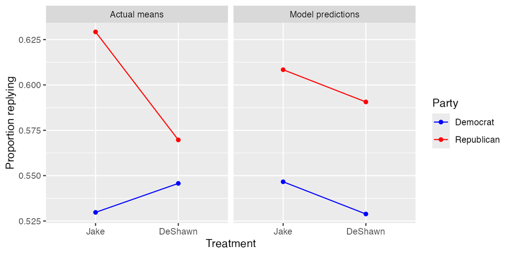

To make predictions match actual means (and allow effect of treatment to vary by party of legislator): add an interaction

## Motivating interactions

We start with

$$Y_i = a_0 + a_1 X_i + a_2 D_i$$

Let’s let $a_2$ depend (linearly) on the value of $X_i$!

$$a_2 = b_0 + b_1 X_i$$

Substitute in
$$Y_i = a_0 + a_1 X_i + (b_0 + b_1 X_i) D_i$$
and rearrange
$$Y_i = a_0 + a_1 X_i + b_0 D_i + b_1 X_i D_i$$

(Same result if we make $a_1$ depend on $D_i$.)

## Adding an interaction

```r
lm(reply_atall ~ treat_deshawn*leg_R, data = bb) |> coef()
```

```
        (Intercept)       treat_deshawn               leg_R treat_deshawn:leg_R
         0.52976190          0.01596300          0.09949293         -0.07550407
```

If we write the prediction equation as
$$\hat{Y}_i = \hat{\beta}_0 + \hat{\beta}_1 \mathrm{DeShawn}_i + \hat{\beta}_2 \mathrm{LegRep}_i + \hat{\beta}_3 \mathrm{DeShawn}_i \times \mathrm{LegRep}_i$$
, then we have

| Email | Recipient | Predicted response rate |
| --- | --- | --- |
| Jake | Dem | $\hat{\beta}_0$ |
| DeShawn | Dem | $\hat{\beta}_0 + \hat{\beta}_1$ |
| Jake | Rep | $\hat{\beta}_0 + \hat{\beta}_2$ |
| DeShawn | Rep | $\hat{\beta}_0 + \hat{\beta}_1 + \hat{\beta}_2 + \hat{\beta}_3$ |

## Another way

You can arrange the regression to tell you means more directly:

```r
bb$email_party <- paste(ifelse(bb$treat_deshawn == 1, "Deshawn", "Jake"),
                        ifelse(bb$leg_R == 0, "D", "R"),
                        sep = "_")
table(bb$email_party)
```

```
Deshawn_D Deshawn_R    Jake_D    Jake_R
     1345      1083      1344      1087
```

```r
lm(reply_atall ~ email_party, data = bb) |> coef()
```

```
         (Intercept) email_partyDeshawn_R    email_partyJake_D    email_partyJake_R
          0.54572491           0.02398885          -0.01596300           0.08352992
```

```r
lm(reply_atall ~ email_party - 1, data = bb) |> coef()
```

```
email_partyDeshawn_D email_partyDeshawn_R    email_partyJake_D    email_partyJake_R
           0.5457249            0.5697138            0.5297619            0.6292548
```

## Takeways

- you decide the form of the BLP: do you want an intercept and coefficients for the non-omitted groups? do you want means for each category?
- if you have only categorical predictors and their interactions (*saturated regression*), OLS gives you sample means for each category (though you may have to combine coefficients to recover those sample means)

# Inference for regression

## Inference for a single coefficient

Inference procedure for a single coefficient $\hat{\beta_1}$ is just like inference for a sample mean:

- (estimated) standard error $\hat{\sigma}[\hat{\beta_1}]$ comes from regression output
- use $\hat{\sigma}[\hat{\beta_1}]$ to produce confidence interval, get $p$-value (probability of coefficient further from null if population coefficient were zero) assuming sampling distribution approximately normal

## Which standard errors?

- *classical* standard errors (default for `lm()`) assume regression errors
  - are **independent**: $\text{Cov}[e_i, e_j] = 0 \, \forall \, i, j$,
  - have **equal variance**: ${\textrm V}[e_i \mid X_i] = {\textrm V}[e_i]$ (*homoskedasticity*)
- *robust* standard errors (default for `estimatr::lm_robust()`) assume regression errors are independent, but may have different variances (*heteroskedasticity*)
- *clustered* standard errors (`clusters` option for `estimatr::lm_robust()`) assume errors may be correlated within defined clusters
- *bootstrap* standard errors: naive version makes same assumption as *robust*; can incorporate clustered sampling

## Inference for combinations of coefficients

Often we are interested in linear combinations of coefficients, e.g.

- because a quantity of interest is estimated by the sum of coefficients: e.g. in interactive model above,
  - estimated reply rate for Democrats receiving Deshawn email is $\hat{\beta}_0 + \hat{\beta}_1$
  - estimated effect of Deshawn email for Republicans is $\hat{\beta}_1 + \hat{\beta}_3$
- because we want to predict the outcome at specific values of the predictors: e.g. $\hat{Y}_i = \hat{\beta}_0 + 2\hat{\beta}_1 + 3\hat{\beta}_1$

If we want a CI or $p$-value, we need the standard error of a (weighted) sum of coefficients.

Recall **variance rule**: in general form,
$${\textrm V}[aX + bY + c] = a^2{\textrm V}[X] + b^2{\textrm V}[Y] + 2 a b \text{Cov}[X, Y]$$

Is e.g. $\text{Cov}[\hat{\beta}_0, \hat{\beta}_1] = 0$ in $Y_i = \hat{\beta}_0 + \hat{\beta}_1 \text{Deshawn}_i$?

## Variance-covariance matrix

```r
intx_reg <- lm(reply_atall ~ treat_deshawn*leg_R, data = bb)
vcov(intx_reg) |> round(5)
```

```
                    (Intercept) treat_deshawn    leg_R treat_deshawn:leg_R
(Intercept)             0.00018      -0.00018 -0.00018             0.00018
treat_deshawn          -0.00018       0.00036  0.00018            -0.00036
leg_R                  -0.00018       0.00018  0.00041            -0.00041
treat_deshawn:leg_R     0.00018      -0.00036 -0.00041             0.00081
```

Standard error of effect of Deshawn email for Republicans:

```r
coef_names <- c("treat_deshawn", "treat_deshawn:leg_R")
(vcov_part <- vcov(intx_reg)[coef_names, coef_names])
```

```
                    treat_deshawn treat_deshawn:leg_R
treat_deshawn        0.0003637887       -0.0003637887
treat_deshawn:leg_R -0.0003637887        0.0008145863
```

```r
(sigma_hat_R <- sqrt(sum(vcov_part))) # V(X) + V(Y) + 2*Cov(X, Y)
```

```
[1] 0.021232
```

## Presenting confidence intervals

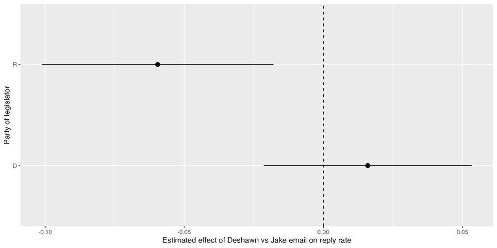

# Polynomials and overfitting

## A dataset

Here is a dataset on U.S. presidential elections from 1948 to 2016:

| Variable Name | Description |
| --- | --- |
| `year` | Election year |
| `deminc` | 1=incumbent is a Democrat |
| `incvote` | Percent of the two-party vote for the incumbent party |
| `q2gdp` | Second-quarter change in real GDP in election year |
| `juneapp` | Net approval of incumbent president in June of election year |

## Incumbent approval rating and incumbent party vote share

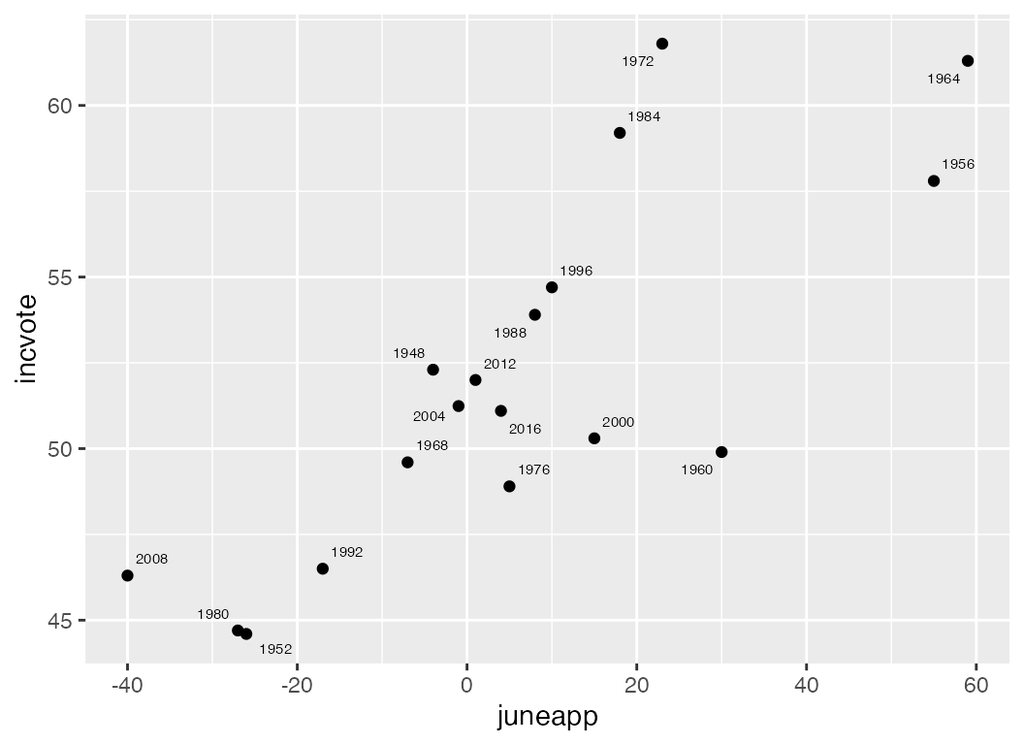

## OLS regression

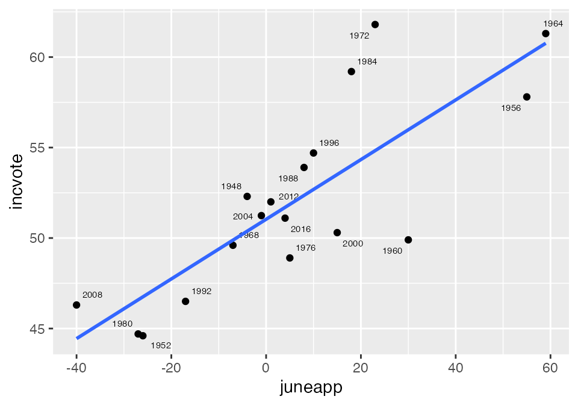

```
Call:
lm(formula = incvote ~ juneapp, data = pres)

Coefficients:
(Intercept)      juneapp
    51.0368       0.1649
```

Avoid causal language in describing the coefficient on `juneapp`. Say e.g.

> “One percentage point higher presidential approval in June is associated with .16 percentage points higher vote share for the president’s party in the November election”

## Adding polynomials three ways (1)

```r
# add variables to data
# base R version
pres2 <- pres
pres2$juneapp_squared <- pres2$juneapp^2
pres2$juneapp_cubed <- pres2$juneapp^3
```

```r
# "tidy" version
pres2 <- pres |>
  mutate(juneapp_squared = juneapp^2,
         juneapp_cubed = juneapp^3)
```

```r
# regression
lm(incvote ~ juneapp + juneapp_squared + juneapp_cubed, data = pres2)
```

```
Call:
lm(formula = incvote ~ juneapp + juneapp_squared + juneapp_cubed,
    data = pres2)

Coefficients:
    (Intercept)          juneapp  juneapp_squared    juneapp_cubed
      5.097e+01        2.165e-01        3.833e-04       -2.811e-05
```

## Adding polynomials three ways (2)

```r
# add variables to formula using I()
lm(incvote ~ juneapp + I(juneapp^2) + I(juneapp^3), data = pres)
```

```
Call:
lm(formula = incvote ~ juneapp + I(juneapp^2) + I(juneapp^3),
    data = pres)

Coefficients:
 (Intercept)       juneapp  I(juneapp^2)  I(juneapp^3)
   5.097e+01     2.165e-01     3.833e-04    -2.811e-05
```

## Adding polynomials three ways (3)

```r
# poly() function
lm(incvote ~ poly(juneapp, degree = 3, raw = T), data = pres) |> summary()
```

```
Call:
lm(formula = incvote ~ poly(juneapp, degree = 3, raw = T), data = pres)

Residuals:
    Min      1Q  Median      3Q     Max
-7.1491 -1.4341  0.3028  1.5728  5.9915

Coefficients:
                                      Estimate Std. Error t value Pr(>|t|)
(Intercept)                          5.097e+01  1.063e+00  47.932  < 2e-16 ***
poly(juneapp, degree = 3, raw = T)1  2.165e-01  7.136e-02   3.034  0.00893 **
poly(juneapp, degree = 3, raw = T)2  3.833e-04  1.560e-03   0.246  0.80955
poly(juneapp, degree = 3, raw = T)3 -2.811e-05  4.131e-05  -0.681  0.50725
---
Signif. codes:  0 '***' 0.001 '**' 0.01 '*' 0.05 '.' 0.1 ' ' 1

Residual standard error: 3.33 on 14 degrees of freedom
Multiple R-squared:  0.6723,    Adjusted R-squared:  0.6021
F-statistic: 9.576 on 3 and 14 DF,  p-value: 0.001076
```

## Plotting polynomial relationships

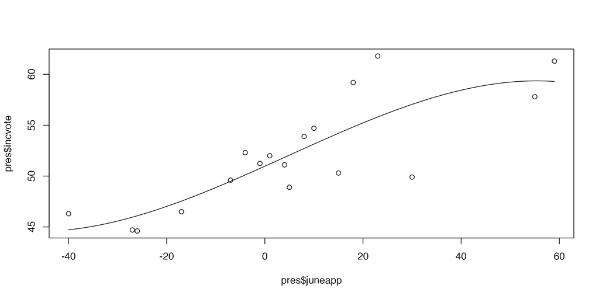

```r
vote_reg <- lm(incvote ~ poly(juneapp, degree = 3, raw = T), data = pres)
juneapps <- data.frame(juneapp = seq(min(pres$juneapp), max(pres$juneapp), length = 100))
predictions <- predict(vote_reg, newdata = juneapps)
plot(pres$juneapp, pres$incvote)
lines(juneapps$juneapp, predictions)
```

## Plotting polynomial relationships

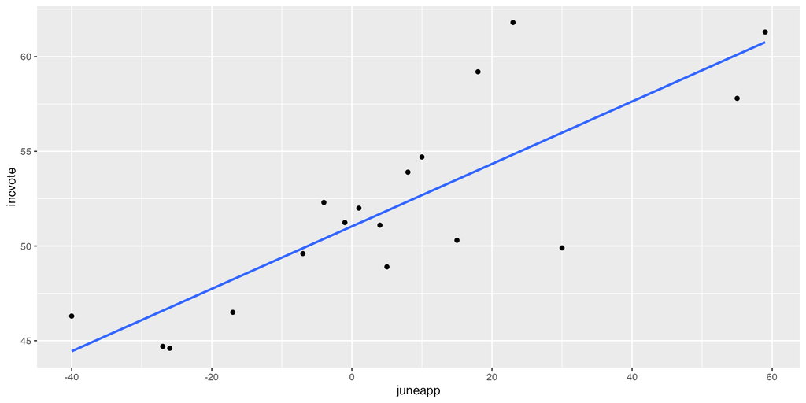

```r
pres |>
  ggplot(aes(x = juneapp, y = incvote)) +
  geom_point() +
  geom_smooth(method = "lm", se = F)
```

## Plotting polynomial relationships

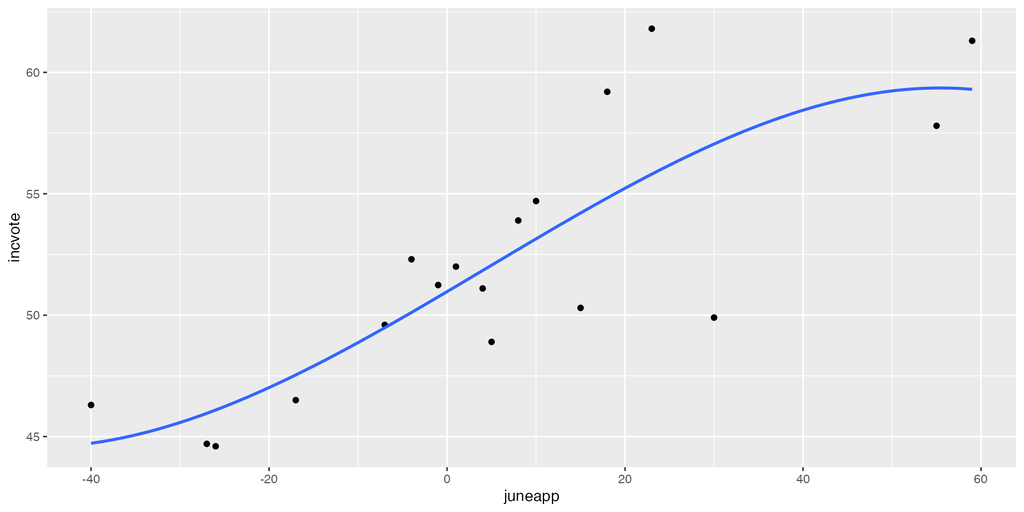

```r
pres |>
  ggplot(aes(x = juneapp, y = incvote)) +
  geom_point() +
  geom_smooth(method = "lm", se = F,
              formula = y ~ poly(x, 3))
```

## Plotting polynomial relationships

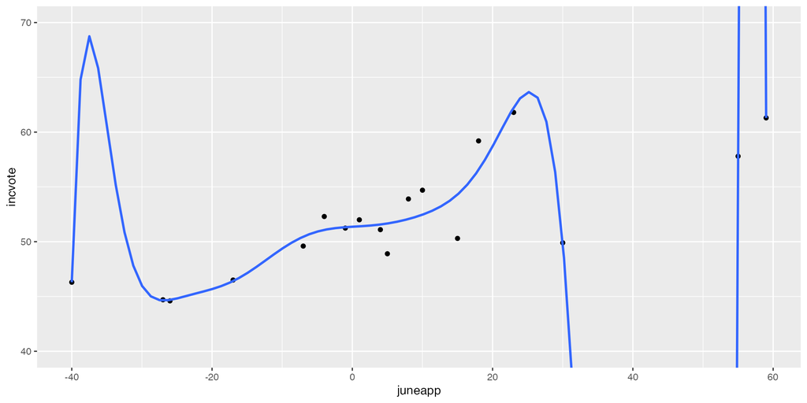

```r
pres |>
  ggplot(aes(x = juneapp, y = incvote)) +
  geom_point() +
  geom_smooth(method = "lm", se = F,
              formula = y ~ poly(x, 12)) +
  coord_cartesian(ylim = c(40, 70))
```

## Overfitting

As you add more polynomials (more generally, add predictors to the model), you reduce the mean squared *residual* (MSE) in the sample. But you may be increasing mean squared residual (MSE) in the **population** due to **overfitting**.

Suppose the dots below are the population, and the red line is the CEF:

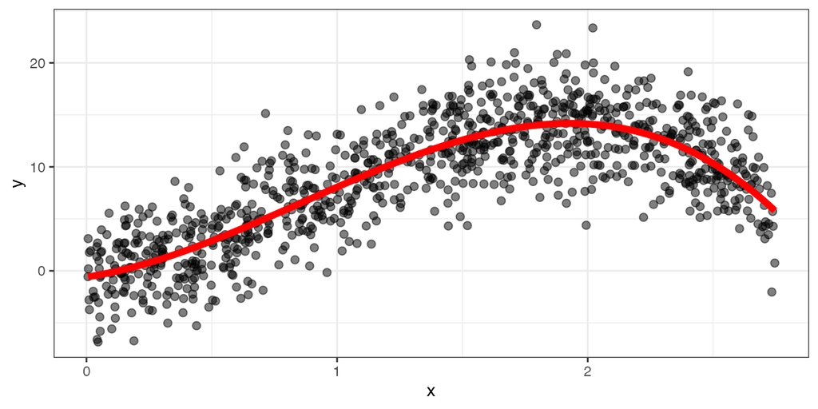

## Overfitting (2)

We will take samples of size $n$ from the population (size $N$) and estimate the BLP with different orders of polynomial $k$:

$$Y_i = \beta_0 + \beta_1 X_i + \beta_2 X_i^2 + \ldots + \beta_k X_i^k$$

As we increase $k$, what will happen to mean squared residual in **sample** (i.e. $\frac{1}{n} \sum (Y_i - \hat{Y}_i)^2$) vs in **population** (i.e. $\frac{1}{N} \sum (Y_i - \hat{Y}_i)^2$)?

How does this depend on sample size $n$?

## Overfitting (3)

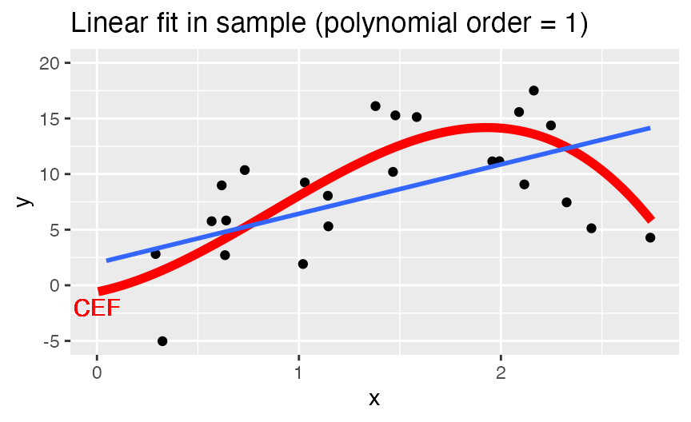

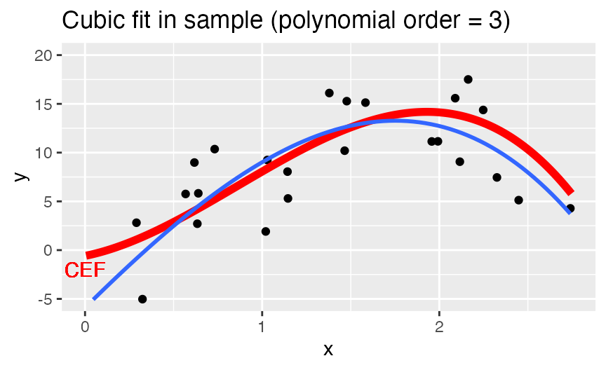

[figure not shown]

## Overfitting (4)

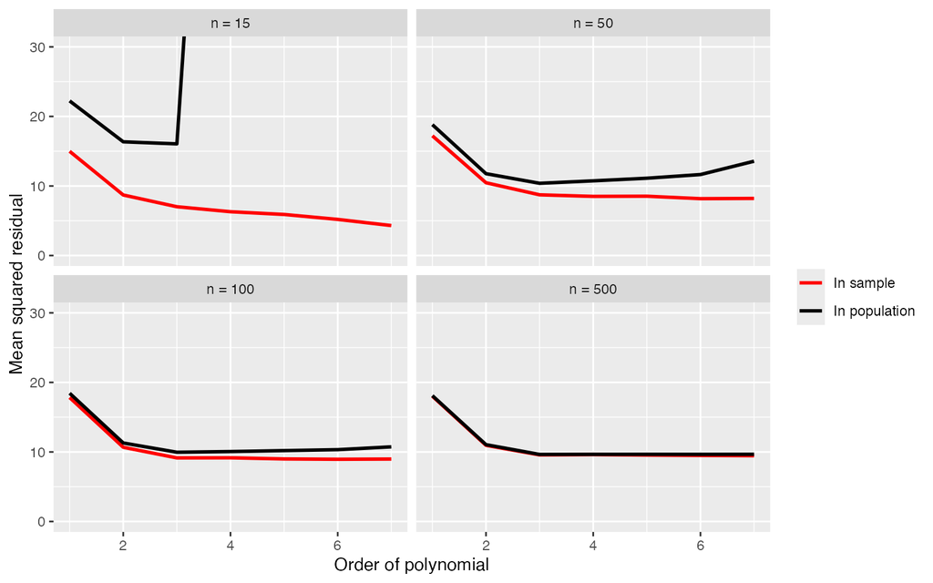

## Takeaways

- we can specify a BLP that is a very flexible function of a predictor $X$ with polynomials, binning, splines
- more flexibility $\rightarrow$ better fit (lower mean squared residuals) **in the sample**
- for small samples, more flexibility $\rightarrow$ worse fit **in the population** due to *over-fitting*